# Replication of Blanchard and Quah SVAR

Aru Bhardwaj (arubhardwaj@hotmail.com)

26 July, 2020

## Introduction

The extraordinary research work of Christopher Sims (1980), Macroeconomics and Reality, introduced the use of Vector Autoregression Models, which significantly affected the Macroeconomics modeling. Further, different economists interpreted the VAR in different ways and proposed further types on it. Blanchard and Quah (1989) proposed a different (SVAR) methodology for interpreting the results of AD and AS shocks. Here, I have replicated the analysis done in Blanchard and Quah (1989).

## Declaring Data in Time Series

R does not know if data is in the time series format! It requires command for introducing data in the time series format, as the code shows, data starts from 1948 second quarter. The plot below shows the graphical description of quarterly time series data on GDP growth and unemployment.

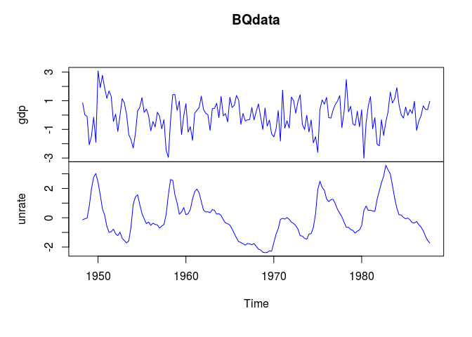

```r
gdp <- ts(data$`GDP Growth`, start = c(1948, 2), frequency = 4)
unrate <- ts(data$Unemployment, start = c(1948, 2), frequency = 4)
BQdata <- cbind(gdp, unrate)

plot.ts(BQdata, col = c('blue'))
```

## Lag length

```r
lagselect <- VARselect(BQdata, type = "both")
lagselect$selection
```

```
## AIC(n)  HQ(n)  SC(n) FPE(n)
##      2      2      2      2
```

## VAR model

Once we know the lag value, which is 2 here, we can compute the VAR model. With the help of `vars` package, computing the model is easy. All we have to use is `VAR()` function, enter the lag values and other information (if required), and the results can be summarized.

```r
VARmodel <- VAR(BQdata, lag.max = 2, season = NULL, exogen = NULL)
summary(VARmodel)
```

```
##
## VAR Estimation Results:
## =========================
## Endogenous variables: gdp, unrate
## Deterministic variables: const
## Sample size: 157
## Log Likelihood: -211.593
## Roots of the characteristic polynomial:
## 0.8361 0.8361 0.1014 0.1014
## Call:
## VAR(y = BQdata, exogen = NULL, lag.max = 2)
##
##
## Estimation results for equation gdp:
## ====================================
## gdp = gdp.l1 + unrate.l1 + gdp.l2 + unrate.l2 + const
##
##           Estimate Std. Error t value Pr(>|t|)
## gdp.l1     0.06903    0.10782   0.640  0.52298
## unrate.l1 -0.61536    0.30723  -2.003  0.04697 *
## gdp.l2     0.04740    0.09098   0.521  0.60317
## unrate.l2  0.90199    0.31426   2.870  0.00469 **
## const     -0.01581    0.07684  -0.206  0.83726
## ---
## Signif. codes:  0 '***' 0.001 '**' 0.01 '*' 0.05 '.' 0.1 ' ' 1
##
##
## Residual standard error: 0.9613 on 152 degrees of freedom
## Multiple R-Squared: 0.2688,  Adjusted R-squared: 0.2495
## F-statistic: 13.97 on 4 and 152 DF,  p-value: 9.998e-10
##
##
## Estimation results for equation unrate:
## =======================================
## unrate = gdp.l1 + unrate.l1 + gdp.l2 + unrate.l2 + const
##
##            Estimate Std. Error t value Pr(>|t|)
## gdp.l1    -0.119154   0.035976  -3.312 0.001157 **
## unrate.l1  1.333497   0.102511  13.008  < 2e-16 ***
## gdp.l2    -0.029880   0.030358  -0.984 0.326555
## unrate.l2 -0.416964   0.104855  -3.977 0.000108 ***
## const     -0.007481   0.025639  -0.292 0.770848
## ---
## Signif. codes:  0 '***' 0.001 '**' 0.01 '*' 0.05 '.' 0.1 ' ' 1
##
##
## Residual standard error: 0.3207 on 152 degrees of freedom
## Multiple R-Squared: 0.9429,  Adjusted R-squared: 0.9414
## F-statistic: 628.1 on 4 and 152 DF,  p-value: < 2.2e-16
##
##
##
## Covariance matrix of residuals:
##            gdp  unrate
## gdp     0.9240 -0.2022
## unrate -0.2022  0.1029
##
## Correlation matrix of residuals:
##            gdp  unrate
## gdp     1.0000 -0.6558
## unrate -0.6558  1.0000
```

## SVAR of Blanchard and Quah (1989) type

`vars` package also allows to compute Blachard and Quah (1989) type SVAR by using `BQ()` function.

```r
BQ <- BQ(VARmodel)
summary(BQ)
```

```
##
## SVAR Estimation Results:
## ========================
##
## Call:
## BQ(x = VARmodel)
##
## Type: Blanchard-Quah
## Sample size: 157
## Log Likelihood: -216.675
##
## Estimated contemporaneous impact matrix:
##           gdp  unrate
## gdp    0.2655 -0.9239
## unrate 0.1746  0.2690
##
## Estimated identified long run impact matrix:
##           gdp unrate
## gdp    0.6200  0.000
## unrate 0.9851  3.223
##
## Covariance matrix of reduced form residuals (*100):
##           gdp unrate
## gdp     92.40 -20.22
## unrate -20.22  10.29
```

## IRF and FEVD

This section is for computing Impulse Response Functions (IRF) and the Forecast Error Variance Decompositions (FEVD). Using `n.ahead` future values can be forecasted, for this analysis 20 values ahead of the data range are determined.

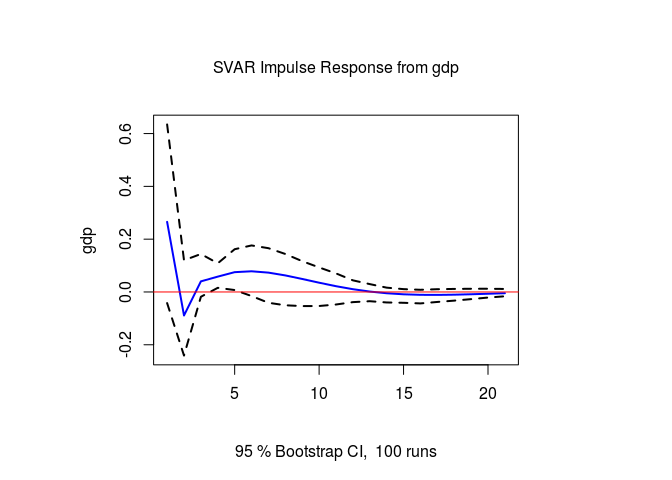

```r
irf1 <- irf(BQ, impulse = 'gdp', response = 'gdp', n.ahead = 20)
plot(irf1, col = c('blue', ' ', 'black'), lwd = 2)
```

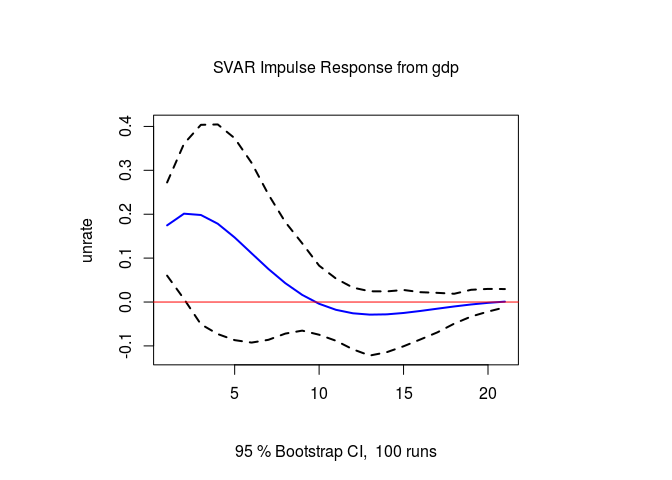

```r
irf2 <- irf(BQ, impulse = 'gdp', response = 'unrate', n.ahead = 20)
plot(irf2, col = c('blue', ' ', 'black'), lwd = 2)
```

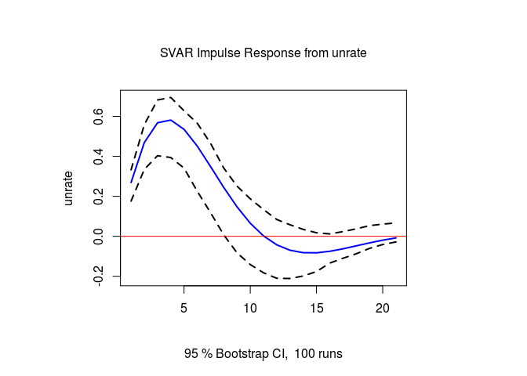

```r
irf3 <- irf(BQ, impulse = 'unrate', response = 'unrate', n.ahead = 20)
plot(irf3, col = c('blue', ' ', 'black'), lwd = 2)
```

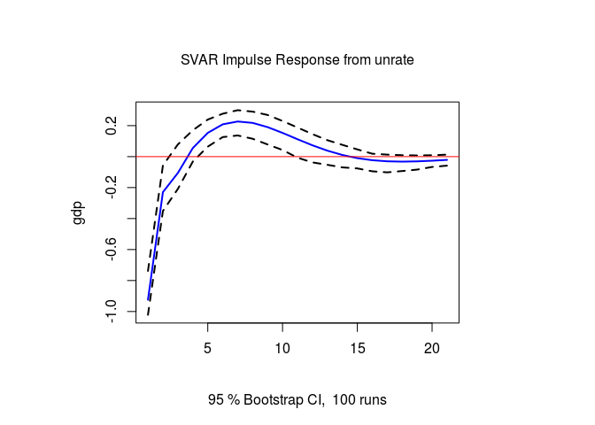

```r
irf4 <- irf(BQ, impulse = 'unrate', response = 'gdp', n.ahead = 20)
plot(irf4, col = c('blue', ' ', 'black'), lwd = 2)
```

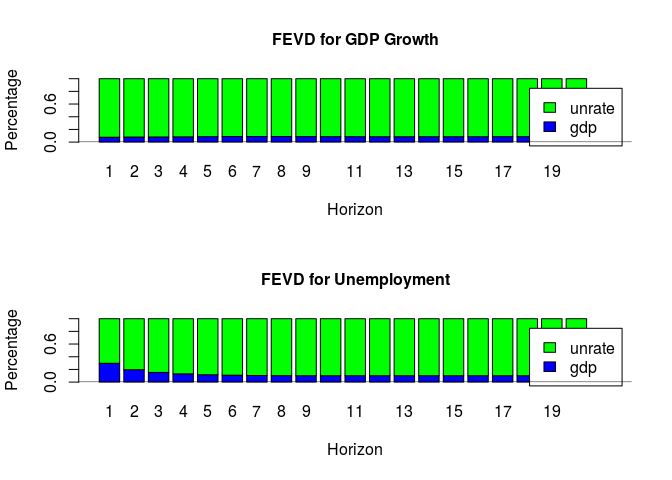

```r
fevd <- fevd(BQ, n.ahead = 20)
plot(fevd, col = c('blue', 'green'),
     main = c("FEVD for GDP Growth", "FEVD for Unemployment"),
     cex.main = 1, cex.axis = 1)
```

## References

Blanchard, O. and Quah, D. (1989), [The Dynamic Effects of Aggregate Demand and Supply Disturbances](https://www.jstor.org/stable/1827924), American Economic Review 79 (4), 655–673.

Sims, C. A. (1980a), [Macroeconomics and Reality](https://www.jstor.org/stable/1912017), Econometrica 48, 1–48.